# Лабораторная работа № 14

Партиции, файловые системы, монтирование

Сергеев Д. О.

Российский университет дружбы народов, Москва, Россия

06 декабря 2025

# Информация

## Докладчик

- Сергеев Даниил Олегович
- Студент
- Направление: Прикладная информатика
- Российский университет дружбы народов
- 1132246837@pfur.ru

# Цель работы

Получить навыки создания разделов на диске и файловых систем. Получить навыки монтирования файловых систем.

# Задание

1. Добавьте два диска на виртуальной машине;
2. Продемонстрируйте навыки создания разделов MBR с помощьюfdisk;
3. Продемонстрируйте навыки создания логических разделов с помощью fdisk;
4. Продемонстрируйте навыки создания раздела подкачки с помощью fdisk;
5. Продемонстрируйте навыки создания разделов GPT с помощью gdisk;
6. Продемонстрируйте навыки форматирования файловой системы XFS;
7. Продемонстрируйте навыки форматирования файловой системы EXT4;
8. Продемонстрируйте навыки ручного монтирования файловых систем;
9. Продемонстрируйте навыки монтирования файловых систем с помощью /etc/fstab;
10. Выполните задание для самостоятельной работы;

# Ход выполнения лабораторной работы

# Создание виртуальных носителей

## Создание виртуальных носителей

Добавим к виртуальной системе Rocky Linux два диска размером 512 МБ. Для этого в VirtualBox откроем меню настройки системы и перейдем во вкладку `Носители`. Добавим новые жёсткие диски для контроллера `SATA`. В появившемся окне нажмем на кнопку `Создать файл образа диска`.

[figure not shown]

Окно создания образа диска

## Создание виртуальных носителей

Назовём первый диск `disk1`, а второй `disk2`. Укажем тип VDI и память - 512 МБ. После нажмем кнопку `Создать`. В окне носителей выберем каждый диск по очереди и нажмем кнопку `Выбрать`, чтобы подключить диски к контроллеру.

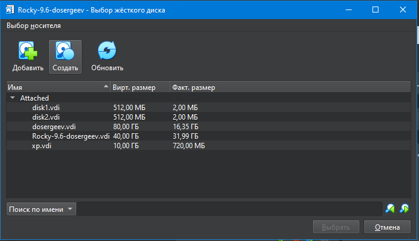

Панель выбора жёсткого диска

# Создание разделов MBR с помощью fdisk

## Создание разделов MBR с помощью fdisk

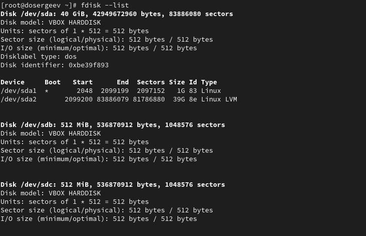

Перечень разделов на жёстких дисках

## Создание разделов MBR с помощью fdisk

Пусть нам необходимо сделать разметку разделов для диска `/dev/sdb`:

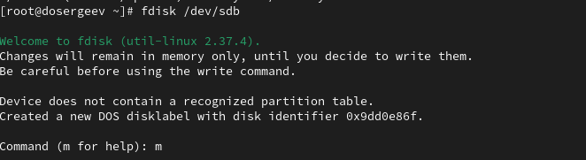

Приветствие программы fdisk

```bash
# используем утилиту fdisk
fdisk /dev/sdb
```

## Создание разделов MBR с помощью fdisk

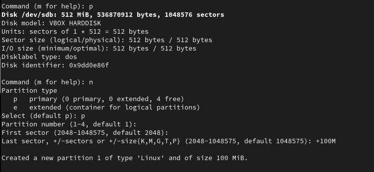

Создание раздела на /dev/sdb

## Создание разделов MBR с помощью fdisk

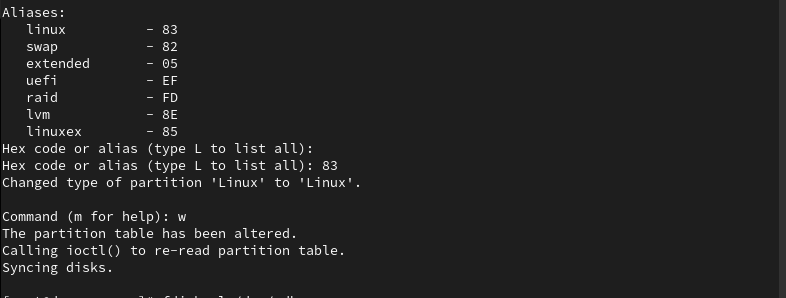

Типы разделов

## Создание разделов MBR с помощью fdisk

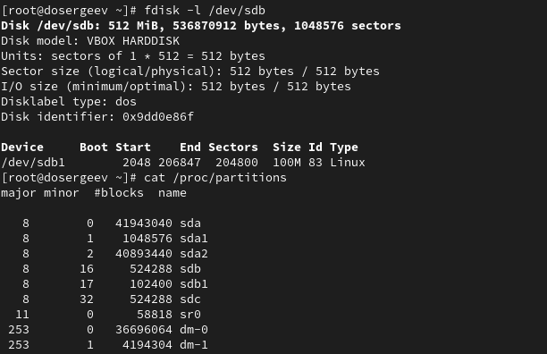

Таблица разделов в разных командах

# Создание логических разделов

## Создание логических разделов

Запустим редактор дисков и создадим новый раздел:

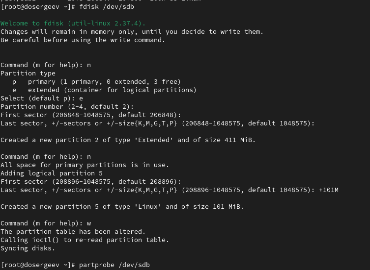

Создание расширенного и логического раздела

```bash
fdisk /dev/sdb
```

## Создание логических разделов

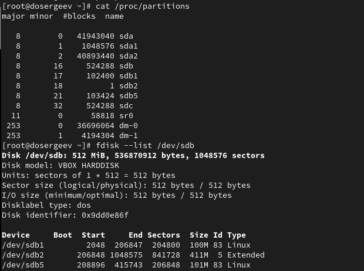

Информация о /dev/sdb2 и /dev/sdb5

# Создание раздела подкачки

## Создание раздела подкачки

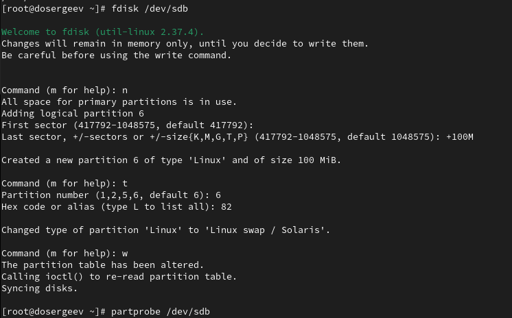

Создание раздела подкачки

## Создание раздела подкачки

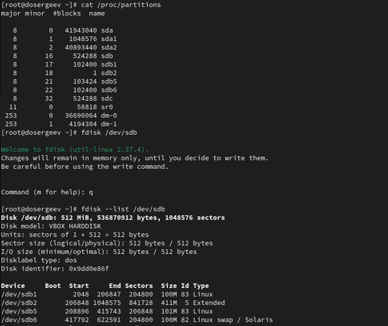

Информация о /dev/sdb6

## Создание раздела подкачки

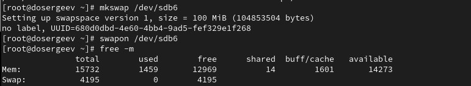

Форматирование /dev/sdb6 и размер пространства подкачки

# Создание разделов GPT с помощью gdisk

## Создание разделов GPT с помощью gdisk

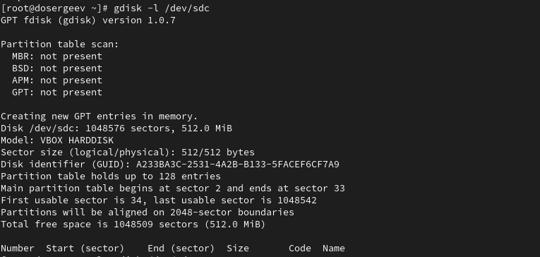

Создание таблицы разделов GPT

Так как разбиение диска отсутствует, создаётся таблица разделов GPT и соответствующее разбиение в памяти.

## Создание разделов GPT с помощью gdisk

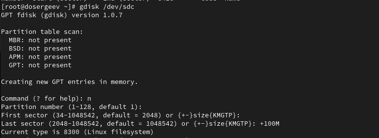

Создание раздела через gdisk

В отличие от `fdisk`, нам предлагается указать тип разбиения. Указываем значение по умолчанию (8300). После создания раздела выведем разбиение диска:

## Создание разделов GPT с помощью gdisk

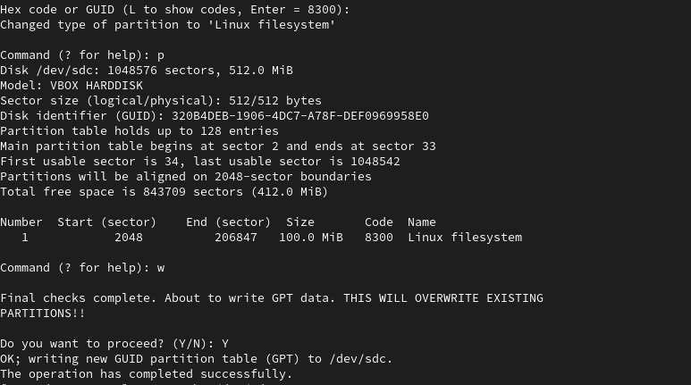

Завершение редактирования в gdisk

## Создание разделов GPT с помощью gdisk

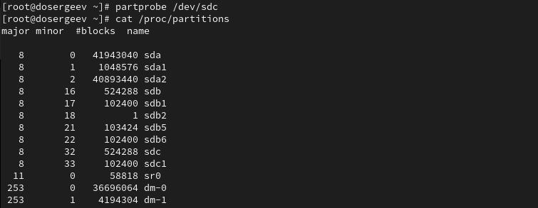

Информация о /dev/sdc (1)

## Создание разделов GPT с помощью gdisk

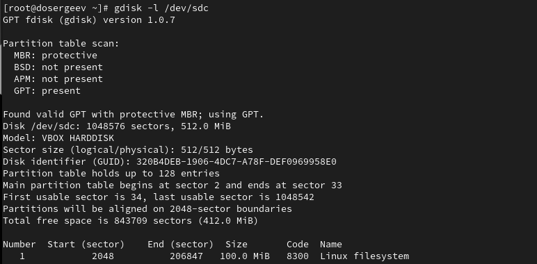

Информация о /dev/sdc (2)

# Форматирование файловой системы XFS

## Форматирование файловой системы XFS

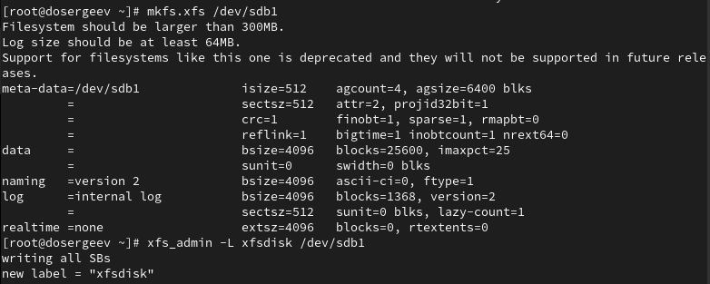

Форматирование файловой системы XFS

# Форматирование файловой системы EXT4

## Форматирование файловой системы EXT4

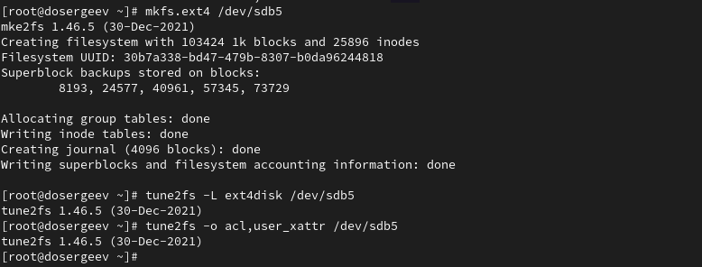

Форматирование файловой системы EXT4

# Ручное монтирование файловых систем

## Ручное монтирование файловых систем

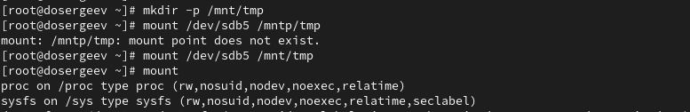

Монтирование файловой системы EXT4 /dev/sdb5 вручную

## Ручное монтирование файловых систем

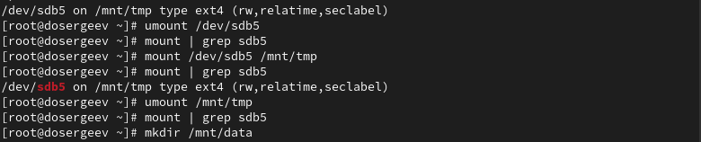

Отмонтирование раздела вручную

# Монтирование разделов с помощью /etc/fstab

## Монтирование разделов с помощью /etc/fstab

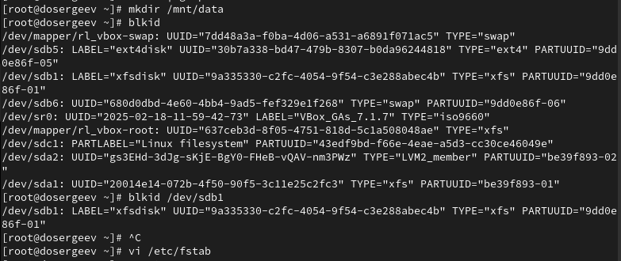

Работа с blkid

## Монтирование разделов с помощью /etc/fstab

Скопируем UUID для этого устройства. Откроем файл `/etc/fstab` на редактирование и добавим в него строку:

```bash
vi /etc/fstab

# В файле
UUID=9a335330-c2fc-4054-9f54-c3e288abec4b /mnt/data xfs defaults 1 2
```

## Монтирование разделов с помощью /etc/fstab

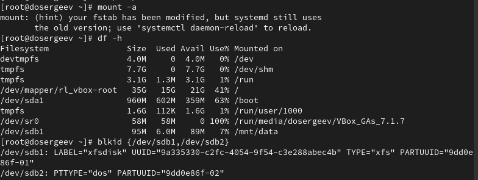

Проверка конфигурации /etc/fstab

# Самостоятельная работа

## Самостоятельная работа

Добавим два раздела по 100 MiB на диск `/dev/sdb` (через `gdisk`).

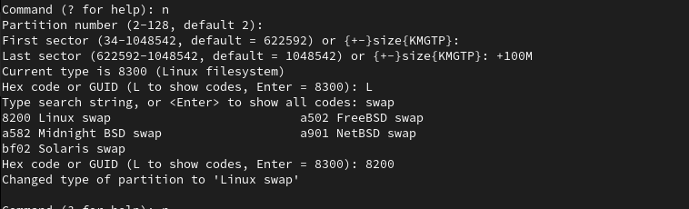

Создание раздела подкачки

## Самостоятельная работа

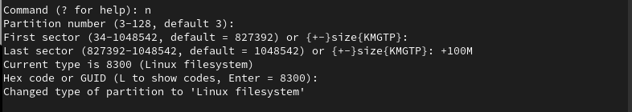

Создание раздела для файловой системы EXT4

## Самостоятельная работа

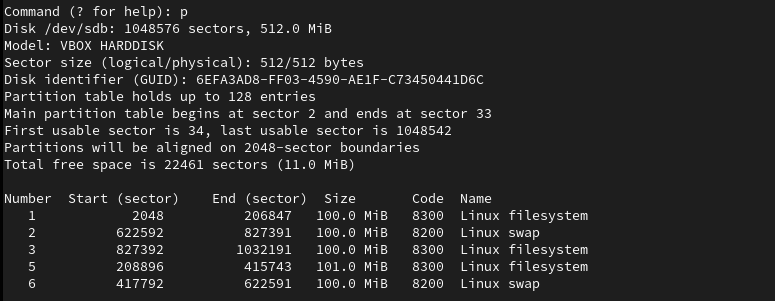

Текущее разбиение

## Самостоятельная работа

Сохраним изменения, нажав `w`, и обновим таблицу разделов.

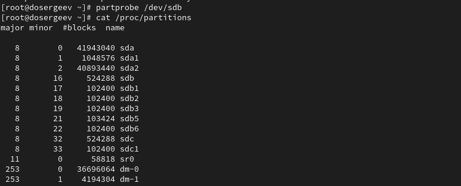

Обновление таблицы разделов

```bash
partprobe /dev/sdb
cat /proc/partitions
```